# Import

```python
# Download font when you run this notebook in Colab

# !sudo apt-get install -y fonts-nanum
# !sudo fc-cache -fv
# !rm ~/.cache/matplotlib -rf
```

```python
import re
import datetime
from collections import Counter
from PIL import Image

import pandas as pd
import numpy as np
import matplotlib.pyplot as plt
import matplotlib.dates as dates
import matplotlib.patches as patches
import seaborn as sns
from wordcloud import WordCloud, ImageColorGenerator

import utils.preprocessing as prep
%matplotlib inline


plt.rc('font', family='NanumGothic')
```

# Load Dataset

```python
youtube = pd.read_csv('dataset/k_youtube_datasets.csv')
youtube.head()
```

|  | url | vid_name | hashtags | views | likes | upload_date | channel_name | channel_subs |
| --- | --- | --- | --- | --- | --- | --- | --- | --- |
| 0 | https://www.youtube.com/watch?v=NgEk5DFcAbA | "한국 미쳤나?" 결승선 통과하는 순간 1초전 카메라에 잡힌 곽윤기 표정 공개되자 ... | #해외반응 #일본반응 #외국인반응 | 208990 | NaN | 2022. 2. 12. | 클립튜브 | 구독자 24.9만명 |
| 1 | https://www.youtube.com/watch?v=deimT6UupoE | 금메달 수상소감중 황대헌의 예상치 못한 참격에 린샤오쥔(임효준) 멘탈 나가버린 이유 | #해외반응 #일본반응 #외국인반응 | 242894 | NaN | 2022. 2. 11. | 클립튜브 | 구독자 24.9만명 |
| 2 | https://www.youtube.com/watch?v=hrvu3jhp43k | "한국에서 저걸 뭐라 부르는줄 알아?" 황대헌 금메달 확정되는 순간 5초전 카메라에... | #해외반응 #일본반응 #외국인반응 | 950227 | NaN | 2022. 2. 10. | 클립튜브 | 구독자 24.9만명 |
| 3 | https://www.youtube.com/watch?v=JxUlSgHLxNo | 결국 심판 시작됐다 "중국 메달조작 3인방 초비상 사태" 상상도 못한 상황 닥치자 ... | #해외반응 #일본반응 #외국인반응 | 1132426 | NaN | 2022. 2. 9. | 클립튜브 | 구독자 24.9만명 |
| 4 | https://www.youtube.com/watch?v=Lfs9P3Atuo8 | "80억 인류가 심판했다" 중국인과 붙는 순간 무더기 실격 참다못한 외국선수들 떠나... | #해외반응 #일본반응 #외국인반응 | 320065 | NaN | 2022. 2. 8. | 클립튜브 | 구독자 24.9만명 |

```python
# 메타 데이터

youtube.info()
```

```
<class 'pandas.core.frame.DataFrame'>
RangeIndex: 9261 entries, 0 to 9260
Data columns (total 8 columns):
 #   Column        Non-Null Count  Dtype
---  ------        --------------  -----
 0   url           9261 non-null   object
 1   vid_name      9261 non-null   object
 2   hashtags      5503 non-null   object
 3   views         9261 non-null   int64
 4   likes         6680 non-null   object
 5   upload_date   9261 non-null   object
 6   channel_name  9261 non-null   object
 7   channel_subs  8085 non-null   object
dtypes: int64(1), object(7)
memory usage: 578.9+ KB
```

# Preprocessing

```python
stopwords = ['이', '을', '를', '에서', '에', '가', '의', '인', '은', '는', '한']

df = youtube.copy()
df = prep.preprocess_all_columns(df)
df = prep.tokenize_vid_name(df, stopwords)
df.head()
```

[output not shown]

| upload_date | url | vid_name | hashtags | views | likes | channel_name | channel_subs | year | tokens |
| --- | --- | --- | --- | --- | --- | --- | --- | --- | --- |
| 2013-08-11 | https://www.youtube.com/watch?v=0emXMyRlJE0 | 한국말 잘하는 영국남자 돼지 | [] | 1475763 | 2.7만 | 영국남자 Korean Englishman | 4.6e+06 | 2013 | [한국말, 잘하는, 영국남자, 돼지] |
| 2013-08-12 | https://www.youtube.com/watch?v=GEIIyqRoI8I | 한국말 잘하는 영국남자 런던 김치 ... | [] | 1638646 | 1.7만 | 영국남자 Korean Englishman | 4.6e+06 | 2013 | [한국말, 잘하는, 영국남자, 런던, 김치] |
| 2013-08-19 | https://www.youtube.com/watch?v=Aed8CqyRa_U | 영국남자의 모자이야기 여우 | [] | 574197 | 9.3천 | 영국남자 Korean Englishman | 4.6e+06 | 2013 | [영국남자, 모자, 이야기, 여우] |
| 2013-08-27 | https://www.youtube.com/watch?v=-PWoOMD8OMw | 영국남자가 드리는 감사인사 ... | [] | 419907 | 9.2천 | 영국남자 Korean Englishman | 4.6e+06 | 2013 | [영국남자, 드리는, 감사인사] |
| 2013-08-31 | https://www.youtube.com/watch?v=UsIM75T177M | 영국남자 한국말로 런던 투어 ... | [] | 1003177 | 1.2만 | 영국남자 Korean Englishman | 4.6e+06 | 2013 | [영국남자, 한국말, 로, 런던, 투어] |

# EDA

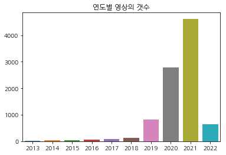

```python
# 연도별 영상의 갯수

temp = df['year'].value_counts()
sns.barplot(temp.index, temp.values)
plt.title('연도별 영상의 갯수')
plt.show()
```

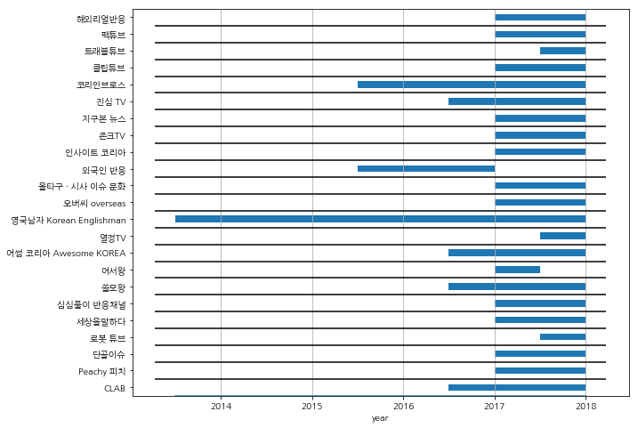

```python
# 유튜버들이 영상을 올린 날짜

temp = df.groupby('channel_name')['year'].agg(['min', 'max'])
# min_date = dates.date2num(temp['min'])
# max_date = dates.date2num(temp['max'])


def plot_rect(data, delta=0.4):
    """data is a dictionary, {"Label":(low,hi), ... }
    return a drawing that you can manipulate, show, save etc"""

    yspan = len(data)
    yplaces = [.5+i for i in range(yspan)]
    ylabels = sorted(data.keys())

    fig = plt.figure(figsize=(10, 8))
    ax = fig.add_subplot(111)
    ax.set_yticks(yplaces)
    ax.set_yticklabels(ylabels)
    ax.set_ylim((0,yspan))

    # later we'll need the min and max in the union of intervals
    low, hi =  data[ylabels[0]]
    for pos, label in zip(yplaces,ylabels):
        start, end = data[label]
        ax.add_patch(patches.Rectangle((start,pos-delta/2.0),end-start,delta))
        if start<low : low=start
        if end>hi : hi=end

    # little small trick, draw an invisible line so that the x axis
    # limits are automatically adjusted...
    ax.plot((low,hi),(0,0))

    # now get the limits as automatically computed
    xmin, xmax = ax.get_xlim()
    # and use them to draw the hlines in your example
    ax.hlines(range(1,yspan),xmin,xmax)
    # the vlines are simply the x grid lines
    ax.grid(axis='x')
    # eventually return what we have done
    return ax

data = {i:(row['min'], row['max']) for i, row in temp.iterrows()}
ax = plot_rect(data)
# so that we can further manipulate it using the `axes` methods, e.g.
ax.set_xlabel('year')
ax.set_xticklabels(range(2013, 2023))
plt.show()
```

```python
# 태그 트렌드의 변화

years = [2019, 2020, 2021, 2022]
hashtag_df = pd.DataFrame(index=list(set(df['hashtags'].apply(eval).sum())))

# 모든 연도에 걸쳐 쓰인 태그의 수의 합
hashtag_df['sum'] = np.zeros(len(hashtag_df))

# 태그의 갯수를 해당 연도의 총 영상 수로 나누어 보정

for year in years:
    temp = df[f'{year}-01-01':f'{year + 1}-01-01']
    hashtag_df[f'{year}'] = np.zeros(len(hashtag_df))
    hashtags_counter = Counter(temp['hashtags'].apply(eval).sum())
    for key, value in hashtags_counter.items():
        hashtag_df.loc[key, f'{year}'] = value / len(temp)
        hashtag_df.loc[key, 'sum'] += value

hashtag_df = hashtag_df.sort_values('sum', ascending=False)

# 전년도 값으로 나누어 얼마나 변화했는지 비율 환산

for year in years[:-1]:
    # devide with zero를 피하기 위해 0을 아주 작은 값으로 치환(0,000001)
    hashtag_df[f'{year}'] = hashtag_df[f'{year}'].replace(0, 0.000001)
    hashtag_df[f'{year}-{year+1}change'] = hashtag_df[f'{year+1}'] / hashtag_df[f'{year}']

hashtag_df.head(10)
```

|  | sum | 2019 | 2020 | 2021 | 2022 | 2019-2020change | 2020-2021change | 2021-2022change |
| --- | --- | --- | --- | --- | --- | --- | --- | --- |
| #해외반응 | 3042.0 | 0.001217 | 0.231977 | 0.442237 | 0.525268 | 190.685225 | 1.906382 | 1.187752 |
| #외국인반응 | 1767.0 | 0.019465 | 0.137045 | 0.269704 | 0.180704 | 7.040685 | 1.967998 | 0.670010 |
| #일본반응 | 1373.0 | 0.025547 | 0.095289 | 0.195854 | 0.272588 | 3.729887 | 2.055367 | 1.391792 |
| #한국 | 1039.0 | 0.087591 | 0.175946 | 0.085727 | 0.117917 | 2.008714 | 0.487233 | 1.375504 |
| #일본 | 680.0 | 0.193431 | 0.091363 | 0.051825 | 0.038285 | 0.472331 | 0.567237 | 0.738738 |
| #외국인 | 639.0 | 0.002433 | 0.043183 | 0.105377 | 0.042879 | 17.748394 | 2.440213 | 0.406911 |
| #네티즌반응 | 216.0 | 0.000001 | 0.025339 | 0.017059 | 0.101072 | 25339.043540 | 0.673228 | 5.924865 |
| #외국반응 | 188.0 | 0.000001 | 0.014989 | 0.028072 | 0.024502 | 14989.293362 | 1.872783 | 0.872847 |
| #중국 | 172.0 | 0.023114 | 0.018915 | 0.019434 | 0.015314 | 0.818325 | 1.027448 | 0.787987 |
| #손흥민 | 165.0 | 0.001217 | 0.033191 | 0.014684 | 0.004594 | 27.282655 | 0.442404 | 0.312877 |

각 해시태그의 갯수를 해당연도에 올라온 영상 수로 나누었다. 우리 팀이 수집한 데이터는 연도별로 영상의 수가 다르고 2022년 데이터의 경우에는 현재인 2월까지의 데이터만 수집할 수 있었으니 단순히 해시태그의 수로 비교를 하면 정보가 왜곡될 가능성이 있다고 생각했다. 이 방법은 영상들중에서 해당 해시태그가 쓰인 영상의 비율을 구하는 것과 같다고 볼 수 있다. 나는 이 수치를 '해시태그의 점유율'이라고 하겠다.

그리고 트렌드를 관찰하기 위해서는 모든 연도에 걸쳐 일반적으로 쓰이는 해시태그가 아니라, 전년도에 비해 늘어난 해시태그를 관찰하는게 맞다고 생각했다. 즉 2019년과 2020년에 각각 100번씩 쓰인 해시태그보단, 2019년엔 쓰이지 않다가 2020년에 20번 쓰인 해시태그가 더 트렌드를 관찰하는데에는 중요하다는 것이다. 그래서 나는 전년도의 해시태그 점유율로 다음해의 점유율을 얼마나 높은 비율로 점유율이 증가했는지 관찰하고자 했다.

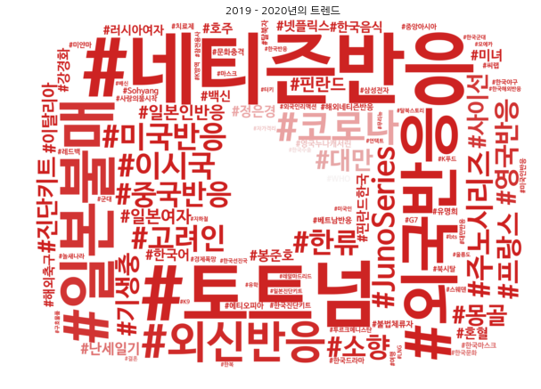

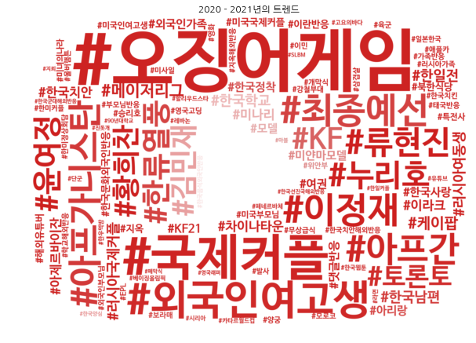

[figure not shown]

```python
# 변화량을 바탕으로 WordCloud 그리기

# wordcloud mask
icon = Image.open('image/youtube-icon-logo.png')    # 마스크가 될 이미지 불러오기

mask = Image.new("RGB", icon.size, (255,255,255))
mask.paste(icon,icon)
mask = np.array(mask)


for year in years[:-1]:
    freq = {i:row[f'{year}-{year+1}change'] for i, row in hashtag_df.iterrows()}

    wc = WordCloud(font_path='font/NanumBarunGothicBold.ttf',
                max_words=100, max_font_size=200,
                scale=4, background_color='white',
                mask=mask,
                random_state=42)

    wc = wc.generate_from_frequencies(freq)

    plt.figure(figsize=(10, 10))
    plt.axis('off')
    image_colors = ImageColorGenerator(mask)
    plt.imshow(wc.recolor(color_func=image_colors),interpolation="bilinear")
    plt.title(f'{year} - {year+1}년의 트렌드' )
    plt.show()
```

2019-2020년 사이의 트렌드를 보면 #네티즌반응, #외신반응 등의 해시태그들이 눈에 띈다. K-유튜버들이 처음 발생했던 2019년의 경우 대부분이 이슈를 정리해 보여주는 이른바 '이슈 유튜버'의 형태였으나 그 영역에서 특히 외국인들의 반응을 집중하여 다루는 유튜버들이 갈라져나왔다. 이 들의 영상에서 나오는 외국인 반응들은 대부분 한국의 장점을 극찬하는 내용을 담고있다. 그리고 2020년은 코로나-19 바이러스가 전세계적으로 퍼지기 시작한 때 였으므로 #코로나, #진단키트 , #이시국등의 해시태그들이 보인다.

2021년은 '오징어 게임'의 해였다. 넷플릭스 드라마 오징어게임은 전세계 넷플릭스에서 1위를 차지함으로써 K-컨텐츠의 위력에 취하기에 딱 좋은 키워드였다. #오징어게임, #이정재, #한류열풍 등의 해시태그들이 보인다. 또한 영화 #미나리와 여기에 출현하여 큰 상을 수상한 #윤여정, 처음으로 100% 한국 기술로 만들어져 쏘아올려진 로켓 #누리호 해시태그가 눈에 띈다. 해외이슈에 관련해서는 미군이 아프가니스탄에서 후퇴한 후 벌어진 사건들을 다루는 #아프가니스탄, #아프간 등의 해시태그들이 보인다.

2022년은 베이징 동계올림픽에 관한 이슈와 여기서 터진 편파판정 논란으로 해시태그들이 뒤덮혔다. #쇼트트랙, #베이징동계올림픽, #황대헌, #한국대표팀, #범내려온다와 같은 해시태그들이 보인다. 또한 최근 인기를 얻은 넷플릭스 드라마 #지금우리학교는 역시 보인다. 지금우리학교는에 대한 해외반응을 다뤘는지 #지금우리학교는해외반응과 같은 해시태그도 보인다.

```python
# 연도별 자주 쓰인 명사

years = [2019, 2020, 2021, 2022]
tokens_df = pd.DataFrame(index=list(set(df['tokens'].sum())))
tokens_df['sum'] = np.zeros(len(tokens_df))

for year in years:
    temp = df[f'{year}-01-01':f'{year + 1}-01-01']
    tokens_df[f'{year}'] = np.zeros(len(tokens_df))
    tokens_counter = Counter(temp['tokens'].sum())
    for key, value in tokens_counter.items():
        tokens_df.loc[key, f'{year}'] = value / len(temp)
        tokens_df.loc[key, 'sum'] += value

tokens_df = tokens_df.sort_values('sum', ascending=False)

for year in years[:-1]:
    tokens_df[f'{year}'] = tokens_df[f'{year}'].replace(0, 0.000001)
    tokens_df[f'{year}-{year+1}change'] = tokens_df[f'{year+1}'] / tokens_df[f'{year}']
tokens_df.head(10)
```

|  | sum | 2019 | 2020 | 2021 | 2022 | 2019-2020change | 2020-2021change | 2021-2022change |
| --- | --- | --- | --- | --- | --- | --- | --- | --- |
| 일본 | 4801.0 | 0.465937 | 0.340471 | 0.657309 | 0.643185 | 0.730724 | 1.930588 | 0.978512 |
| 이유 | 3182.0 | 0.251825 | 0.392577 | 0.369899 | 0.248086 | 1.558928 | 0.942232 | 0.670686 |
| 한국 | 2859.0 | 0.229927 | 0.273019 | 0.363420 | 0.339969 | 1.187417 | 1.331116 | 0.935471 |
| 반응 | 2083.0 | 0.180049 | 0.183084 | 0.255236 | 0.367534 | 1.016856 | 1.394099 | 1.439976 |
| 해외반응 | 1904.0 | 0.000001 | 0.143826 | 0.285683 | 0.272588 | 143825.838687 | 1.986315 | 0.954161 |
| 상황 | 1477.0 | 0.057178 | 0.124197 | 0.207946 | 0.182236 | 2.172126 | 1.674327 | 0.876359 |
| 미국 | 1366.0 | 0.126521 | 0.154532 | 0.158929 | 0.142420 | 1.221401 | 1.028450 | 0.896121 |
| 외국 | 1180.0 | 0.076642 | 0.134190 | 0.142734 | 0.122511 | 1.750858 | 1.063670 | 0.858322 |
| 중국 | 1101.0 | 0.076642 | 0.084226 | 0.136903 | 0.257274 | 1.098943 | 1.625439 | 1.879237 |
| 난 | 767.0 | 0.031630 | 0.065667 | 0.104297 | 0.113323 | 2.076099 | 1.588264 | 1.086541 |

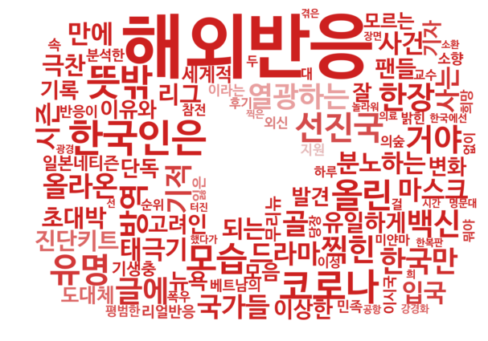

[figure not shown]

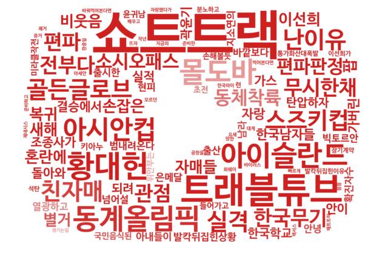

```python
for year in years[:-1]:
    freq = {i:row[f'{year}-{year+1}change'] for i, row in tokens_df.iterrows()}

    wc = WordCloud(font_path='font/NanumBarunGothicBold.ttf',
                max_words=100, max_font_size=200,
                scale=4, background_color='white',
                mask=mask,
                random_state=42)

    wc = wc.generate_from_frequencies(freq)

    plt.figure(figsize=(10, 10))
    plt.axis('off')
    image_colors = ImageColorGenerator(mask)
    plt.imshow(wc.recolor(color_func=image_colors),interpolation="bilinear")
    plt.show()
```

단어를 통해 진행한 트렌드분석도 해시태그로 진행한 결과와 크게 다르지 않았다. 토크나이저가 완벽하지 않아 명사가 아닌 단어도 섞였고 조사가 분리되지 않은 단어도 있어 보기에 좀 더 어렵긴하지만 대체적으로 2020(코로나, 해외반응) -> 2021(오징어게임, 아프간) -> 2022(베이징올림픽)의 트렌드 변화를 보여준다. 다만 해시태그 분석에선 보이지 않았던 2021년 요소수 대란에 관한 키워드를 새롭게 보여주었다.

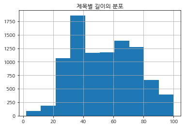

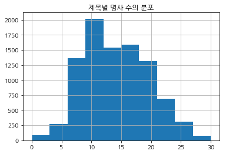

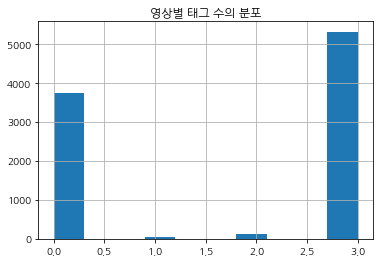

```python
# 그 외 유튜브 제목, 태그에 대한 통계

# 제목별 길이의 분포

df['vid_name'].apply(len).hist()
plt.title('제목별 길이의 분포')
plt.show()

# 제목별 명사 수의 분포

df['tokens'].apply(len).hist()
plt.title('제목별 명사 수의 분포')
plt.show()

# 영상별 태그 수의 분포

df['hashtags'].apply(eval).apply(len).hist()
plt.title('영상별 태그 수의 분포')
plt.show()
```

마지막으로 제목과 태그 수에 관한 간단한 분석을 거쳤다. 영상 제목들의 길이는 20자부터 80자까지 범위가 넓은 편이었으며, 명사의 수로 세보면 대부분 10~20개의 명사를 사용했다. 태그의 경우는 3개이상의 태그를 사용한 영상이 가장 많았지만 태그를 사용하지 않은 영상도 많다는 것을 알 수 있었다.